# Modeling and prediction for movies

## Setup

### Load packages

```r
library(ggplot2)
library(dplyr)
library(statsr)
library(GGally)
library(olsrr)
library(kableExtra)
library(gridExtra)
```

### Load data

```r
load("movies.Rdata")
```

## Part 1: Data

The dataset for this research consists of 651 randomly sampled movies shot and released before 2016. It is collected from Rotten Tomatoes, an American review-aggregation website for films and televisions, and IMDB, an online database.

### Generalization and causality

The result of this research can be generalizable because random sampling is conducted while collecting data.

However, since there is no random assignment in the data collection, we cannot conclude any causal relationship between responsive variables and explanatory variables.

## Part 2: Research question

**Question:** Is it possible to predict the popularity of a movie, based on its features?

For those who are interested in movie assessing, just as I am, the result of this research can give directions, through which the exploration of what causes a movie to be popular will become much easier.

## Part 3: Exploratory data analysis

### 3.1 Data preperation

#### 3.1.1 Definition of “popularity”

The first crucial step of this research is to define the subjective conecpt “popularity”.

In this research, “popularity” is considered as the rating from the general public, which relates to `imdb_rating` and `audience_score`.

- `imdb_rating`: Rating on IMDB (ranging from 0 to 10)
- `audience_score`: Audience score on Rotten Tomatoes (ranging from 0 to 100)

To quantify “popularity”, a new variable `pop` is creatd by giving the same weight to both variables and then scaling `imdb_rating` to match `audience_score`.

$$pop=imdb\_rating*10/2+audience\_score/2$$

#### 3.1.2 Filtering explanatory variables

The research has a few reasonable assumptions as follow, which can be lifted in further researches.

- The title of the movie has no relation with popularity
- The releasing dates of the movie and its DVD do not correlate popularity

Considering that winning best actors, actresses, and the best director in Oscar reflects the impact of actors and directors , we rule out all the variables with the names of actors and directors .

At last, we drop entries with null values and get a new dataset `mdb`.

```r
# Create a new dataset for the research
mdb <- movies %>%
  filter(!is.na(runtime)) %>%
  mutate(pop=imdb_rating*5+audience_score/2) %>%
  select(pop,runtime,critics_score,mpaa_rating,genre,best_pic_nom,best_pic_win,best_actor_win,best_actress_win,best_dir_win,top200_box)
```

### 3.2 Exploratory Data Analysis

```r
summary(mdb)
```

```
##       pop           runtime      critics_score     mpaa_rating
##  Min.   :17.50   Min.   : 39.0   Min.   :  1.00   G      : 19
##  1st Qu.:52.50   1st Qu.: 92.0   1st Qu.: 33.00   NC-17  :  2
##  Median :65.50   Median :103.0   Median : 61.00   PG     :118
##  Mean   :63.63   Mean   :105.8   Mean   : 57.65   PG-13  :133
##  3rd Qu.:76.00   3rd Qu.:115.8   3rd Qu.: 83.00   R      :329
##  Max.   :93.50   Max.   :267.0   Max.   :100.00   Unrated: 49
##
##                 genre     best_pic_nom best_pic_win best_actor_win
##  Drama             :305   no :628      no :643      no :557
##  Comedy            : 87   yes: 22      yes:  7      yes: 93
##  Action & Adventure: 65
##  Mystery & Suspense: 59
##  Documentary       : 51
##  Horror            : 23
##  (Other)           : 60
##  best_actress_win best_dir_win top200_box
##  no :578          no :607      no :635
##  yes: 72          yes: 43      yes: 15
##
##
##
##
##
```

From the above summary, it is easy to group all the variables into two groups:

**Numerical:**

- `pop`: The popularity of a movie
- `runtime`: Runtime of movie (in minutes)
- `critics_score`: Critics score on Rotten Tomatoes

**Categorical:**

- `mpaa_rating`: MPAA rating of the movie (G, PG, PG-13, R, Unrated)
- `genre`: Genre of movie (Action & Adventure, Comedy, Documentary, Drama, Horror, Mystery & Suspense, Other)
- `best_pic_nom`: Whether or not the movie was nominated for a best picture Oscar (no, yes)
- `best_pic_win`: Whether or not the movie won a best picture Oscar (no, yes)
- `best_actor_win`: Whether or not one of the main actors in the movie ever won an Oscar (no, yes) – note that this is not necessarily whether the actor won an Oscar for their role in the given movie
- `best_actress_win`: Whether or not one of the main actresses in the movie ever won an Oscar (no, yes) – not that this is not necessarily whether the actresses won an Oscar for their role in the given movie
- `best_dir_win`: Whether or not the director of the movie ever won an Oscar (no, yes) – not that this is not necessarily whether the director won an Oscar for the given movie
- `top200_box`: Whether or not the movie is in the Top 200 Box Office list on BoxOfficeMojo (no, yes)

```r
summary(mdb$pop)
```

```
##    Min. 1st Qu.  Median    Mean 3rd Qu.    Max.
##   17.50   52.50   65.50   63.63   76.00   93.50
```

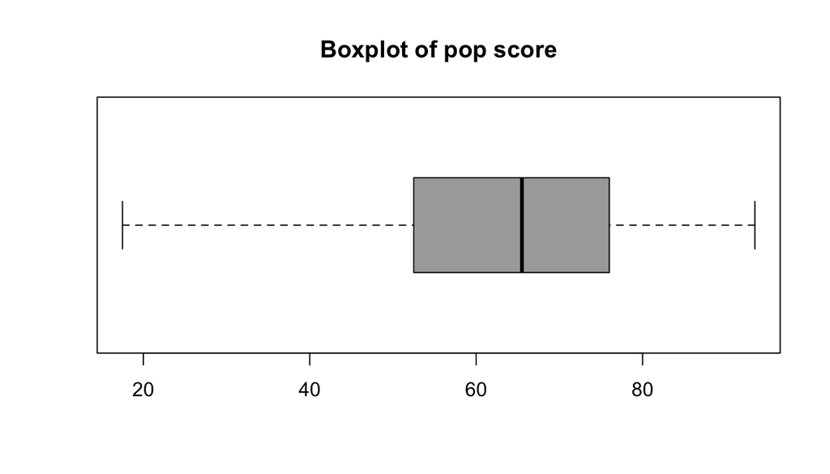

```r
boxplot(mdb$pop,main="Boxplot of pop score",col="darkgray",horizontal = TRUE, notch= FALSE)
```

`pop` score ranges from 17.5 to 93.5. Its range is 76, even larger than the mean and median.

Before modelling, we will first explore if numerical exlanatory variables are linear correlated with responsible variable `pop`.

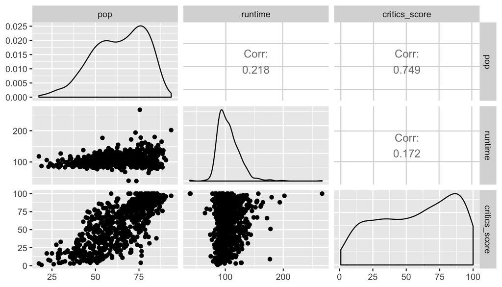

```r
ggpairs(mdb, columns = c(1,2,3))
```

The above graphs indicate that there is a strong correlation between `critics_score` and `pop` while `runtime` is not strong related to `pop`, suggested by the correlation coefficent of 0.218. But from the scatterplot, the relationship between `runtime` and `pop` could still be considered weak linear.

The long tail of the right skewed pattern of `runtime` distribution suggests that there may be a few extreme values.

```r
summary(mdb$runtime)
```

```
##    Min. 1st Qu.  Median    Mean 3rd Qu.    Max.
##    39.0    92.0   103.0   105.8   115.8   267.0
```

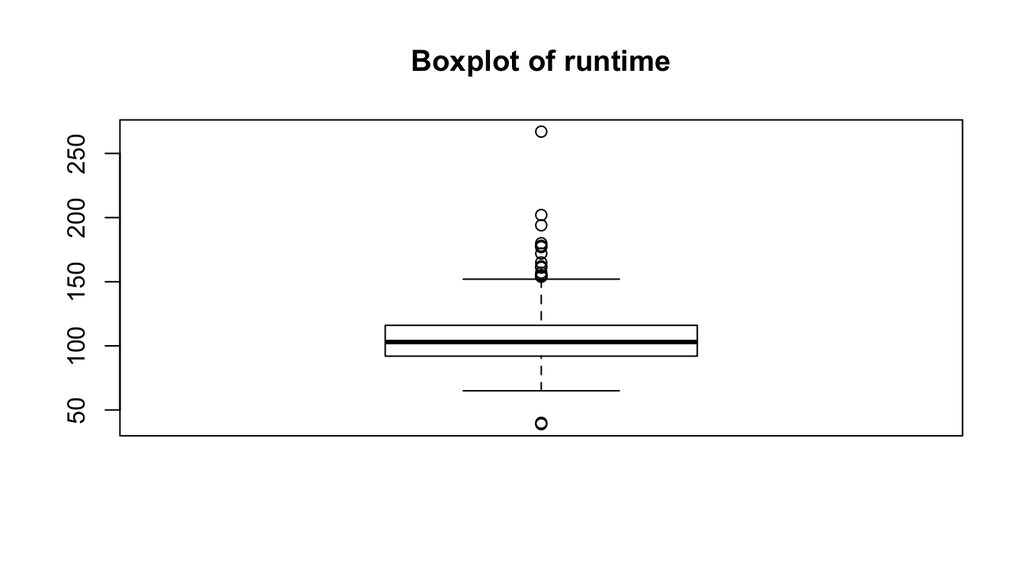

```r
boxplot(mdb$runtime, main="Boxplot of runtime")
```

This could be confirmed by the above summary and boxplot. However, we will not exclude these outliers in this research as we do not have strong evidence to rule them out.

It is logic to belive that the genre of a moive has no relationship with the popularity defined in this research because movies of each type only attract its target customers and the audience will not rise or lower his or her rating simply because of its movie category.

```r
# Calculate pop score by genre
g_1 <-mdb %>%
  group_by(genre) %>%
  summarise(ave_pop=mean(pop))
kable(g_1) %>%
  kable_styling(bootstrap_options="striped", position="left", full_width = F)
```

| genre | ave_pop |
| --- | --- |
| Action & Adventure | 56.74615 |
| Animation | 60.72222 |
| Art House & International | 65.07143 |
| Comedy | 54.97701 |
| Documentary | 79.73529 |
| Drama | 66.04098 |
| Horror | 51.71739 |
| Musical & Performing Arts | 76.58333 |
| Mystery & Suspense | 60.37288 |
| Other | 66.50000 |
| Science Fiction & Fantasy | 54.22222 |

[figure not shown]

```r
# Plot pop score by genre
ggplot(data=g_1, aes(x=genre,y=ave_pop))+
  geom_bar(stat="identity")+
  ggtitle("Average popularity score by MPAA rating")+
  geom_text(aes(label=round(ave_pop,2)),vjust=1.8, size=3, color="white")+
  theme(plot.title = element_text(hjust=0.5, size=9), axis.text.x=element_text(angle=-75, hjust=0.1))+
  labs(y="Average pop score", x="Genre")
```

However, both the table and the bar plot suggest that the average pop score varies by genre, with the documentary scoring 79.74, the highest rating, and horror scoring 51.72, the lowest rating.

We will further explore how explanatory variables relate to responsive variable `pop`.

## Part 4: Modeling

Based on the EDA, which shows the linear relationship between the numerical explanatory variables and responsive variables, we will build a multiple linear regression model in this research.

### 4.1 Model Selection

Since the reliabity of the model prediction is most concerned, we prefer adjusted $R^2$ rather than p-value in model selection. To build a parsimonious model with backwards elimination, we will start with a full model. Then, creates new models by dropping one variable at a time. From all alternatives, we select the model with the highest increase in adjusted $R^2$ and drop variables to create a new group of model. The cycle will keep going until none of the models yield an increase in adjusted $R^2$ .

#### Inital Model

```r
m_pop <-lm(pop ~runtime+critics_score+mpaa_rating+genre+best_pic_nom+best_pic_win+best_actor_win+best_actress_win+best_dir_win+top200_box, data=mdb)

summary(m_pop)
```

```
##
## Call:
## lm(formula = pop ~ runtime + critics_score + mpaa_rating + genre +
##     best_pic_nom + best_pic_win + best_actor_win + best_actress_win +
##     best_dir_win + top200_box, data = mdb)
##
## Residuals:
##      Min       1Q   Median       3Q      Max
## -27.7543  -6.2926   0.4315   6.3815  27.7107
##
## Coefficients:
##                                Estimate Std. Error t value Pr(>|t|)
## (Intercept)                    36.75674    3.45159  10.649  < 2e-16 ***
## runtime                         0.07147    0.02299   3.109  0.00196 **
## critics_score                   0.34315    0.01580  21.715  < 2e-16 ***
## mpaa_ratingNC-17               -8.40411    7.30521  -1.150  0.25041
## mpaa_ratingPG                  -2.12136    2.66282  -0.797  0.42595
## mpaa_ratingPG-13               -2.53406    2.74304  -0.924  0.35594
## mpaa_ratingR                   -1.27696    2.64979  -0.482  0.63004
## mpaa_ratingUnrated             -3.02461    3.02187  -1.001  0.31726
## genreAnimation                  1.43437    3.77207   0.380  0.70388
## genreArt House & International  5.30400    2.91095   1.822  0.06892 .
## genreComedy                    -0.72950    1.61400  -0.452  0.65144
## genreDocumentary                8.88726    2.18924   4.060 5.54e-05 ***
## genreDrama                      1.70909    1.40990   1.212  0.22589
## genreHorror                    -5.21537    2.40185  -2.171  0.03028 *
## genreMusical & Performing Arts  7.32705    3.10152   2.362  0.01846 *
## genreMystery & Suspense        -1.41910    1.81087  -0.784  0.43354
## genreOther                      0.75030    2.73448   0.274  0.78388
## genreScience Fiction & Fantasy -5.68993    3.42916  -1.659  0.09756 .
## best_pic_nomyes                 6.57325    2.49979   2.630  0.00876 **
## best_pic_winyes                -0.97882    4.39179  -0.223  0.82371
## best_actor_winyes              -0.88092    1.14671  -0.768  0.44265
## best_actress_winyes            -1.18543    1.26940  -0.934  0.35074
## best_dir_winyes                 0.22562    1.66263   0.136  0.89210
## top200_boxyes                   2.79210    2.62096   1.065  0.28715
## ---
## Signif. codes:  0 '***' 0.001 '**' 0.01 '*' 0.05 '.' 0.1 ' ' 1
##
## Residual standard error: 9.614 on 626 degrees of freedom
## Multiple R-squared:  0.6067, Adjusted R-squared:  0.5923
## F-statistic: 41.99 on 23 and 626 DF,  p-value: < 2.2e-16
```

**Comments:** The adjusted $R^2$ for initial model is 0.5923. In the first round of elmination, we will look for models whose adjusted $R^2$ is larger than 0.5923.

#### Round 1

```r
m_1 <-lm(pop ~critics_score+mpaa_rating+genre+best_pic_nom+best_pic_win+best_actor_win+best_actress_win+best_dir_win+top200_box, data=mdb)

m_2 <-lm(pop ~runtime+mpaa_rating+genre+best_pic_nom+best_pic_win+best_actor_win+best_actress_win+best_dir_win+top200_box, data=mdb)

m_3 <-lm(pop ~runtime+critics_score+genre+best_pic_nom+best_pic_win+best_actor_win+best_actress_win+best_dir_win+top200_box, data=mdb)

m_4 <-lm(pop ~runtime+critics_score+mpaa_rating+best_pic_nom+best_pic_win+best_actor_win+best_actress_win+best_dir_win+top200_box, data=mdb)

m_5 <-lm(pop ~runtime+critics_score+mpaa_rating+genre+best_pic_win+best_actor_win+best_actress_win+best_dir_win+top200_box, data=mdb)

m_6 <-lm(pop ~runtime+critics_score+mpaa_rating+genre+best_pic_nom+best_actor_win+best_actress_win+best_dir_win+top200_box, data=mdb)

m_7 <-lm(pop ~runtime+critics_score+mpaa_rating+genre+best_pic_nom+best_pic_win+best_actress_win+best_dir_win+top200_box, data=mdb)

m_8 <-lm(pop ~runtime+critics_score+mpaa_rating+genre+best_pic_nom+best_pic_win+best_actor_win+best_actress_win+best_dir_win+top200_box, data=mdb)

m_9 <-lm(pop ~runtime+critics_score+mpaa_rating+genre+best_pic_nom+best_pic_win+best_actor_win+best_dir_win+top200_box, data=mdb)

m_10 <-lm(pop ~runtime+critics_score+mpaa_rating+genre+best_pic_nom+best_pic_win+best_actor_win+best_actress_win+best_dir_win, data=mdb)

colnm=c("runtime","critics_score","mpaa_rating","genre","best_pic_nom","best_pic_win","best_actor_win","best_actress_win","best_dir_win","top200_box")

v=c(summary(m_1)$adj.r.squared,summary(m_2)$adj.r.squared,summary(m_3)$adj.r.squared,summary(m_4)$adj.r.squared,summary(m_5)$adj.r.squared,summary(m_6)$adj.r.squared,summary(m_7)$adj.r.squared,summary(m_8)$adj.r.squared,summary(m_9)$adj.r.squared,summary(m_10)$adj.r.squared)
```

```r
kable(data.frame(Round1_Elimination=colnm,Adjusted_R_Squared=v)) %>%
  kable_styling(bootstrap_options="striped", position="left", full_width = F)
```

[output not shown]

**Round 1 Comments:** The model dropping `mpaa_rating` has the highest adjusted $R^2$,that is,0.5930493. So we will use this model for the next round of elimination.